# Visualisation Project

Mohit Kumar Jain MDS202219

2022-11-02

Link to the dashboard: https://mohitsm18.shinyapps.io/Visualisation_Project/

Link to the video: https://youtu.be/Q6hw5R9I7KU

DATA DESCRIPTION: The data set contains the following information about matches played in the IPL from 2008 to 2019 except those abandoned without a ball being bowled: Teams involved Venue and City Toss and Result Winner and Win margin Officials involved Player of the match

number of matches played in the IPL from 2008 to 2019 except those abandoned without a ball being bowled

```
## [1] 756
```

how the data looks like:

|  | season | city | date | team1 | team2 | toss_winner | toss_decision | result | dl_applied | winner | win_by_runs | win_by_wickets | player_of_match | venue | umpire1 | umpire2 |
| --- | --- | --- | --- | --- | --- | --- | --- | --- | --- | --- | --- | --- | --- | --- | --- | --- |
| 1 | 2008 | Bengaluru | 04-18-2008 | Kolkata Knight Riders | Royal Challengers Bangalore | Royal Challengers Bangalore | field | normal | 0 | Kolkata Knight Riders | 140 | 0 | BB McCullum | M Chinnaswamy Stadium | Asad Rauf | RE Koertzen |
| 2 | 2008 | Chandigarh | 04-19-2008 | Chennai Super Kings | Kings XI Punjab | Chennai Super Kings | bat | normal | 0 | Chennai Super Kings | 33 | 0 | MEK Hussey | Punjab Cricket Association Stadium, Mohali | MR Benson | SL Shastri |
| 3 | 2008 | Delhi | 04-19-2008 | Rajasthan Royals | Delhi Daredevils | Rajasthan Royals | bat | normal | 0 | Delhi Daredevils | 0 | 9 | MF Maharoof | Feroz Shah Kotla | Aleem Dar | GA Pratapkumar |
| 4 | 2008 | Mumbai | 04-20-2008 | Mumbai Indians | Royal Challengers Bangalore | Mumbai Indians | bat | normal | 0 | Royal Challengers Bangalore | 0 | 5 | MV Boucher | Wankhede Stadium | SJ Davis | DJ Harper |
| 5 | 2008 | Kolkata | 04-20-2008 | Deccan Chargers | Kolkata Knight Riders | Deccan Chargers | bat | normal | 0 | Kolkata Knight Riders | 0 | 5 | DJ Hussey | Eden Gardens | BF Bowden | K Hariharan |
| 6 | 2008 | Jaipur | 04-21-2008 | Kings XI Punjab | Rajasthan Royals | Kings XI Punjab | bat | normal | 0 | Rajasthan Royals | 0 | 6 | SR Watson | Sawai Mansingh Stadium | Aleem Dar | RB Tiffin |

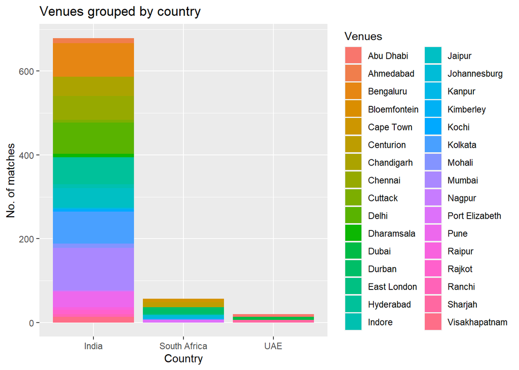

Above is a visual representation of the different venues and the amount of cricket played

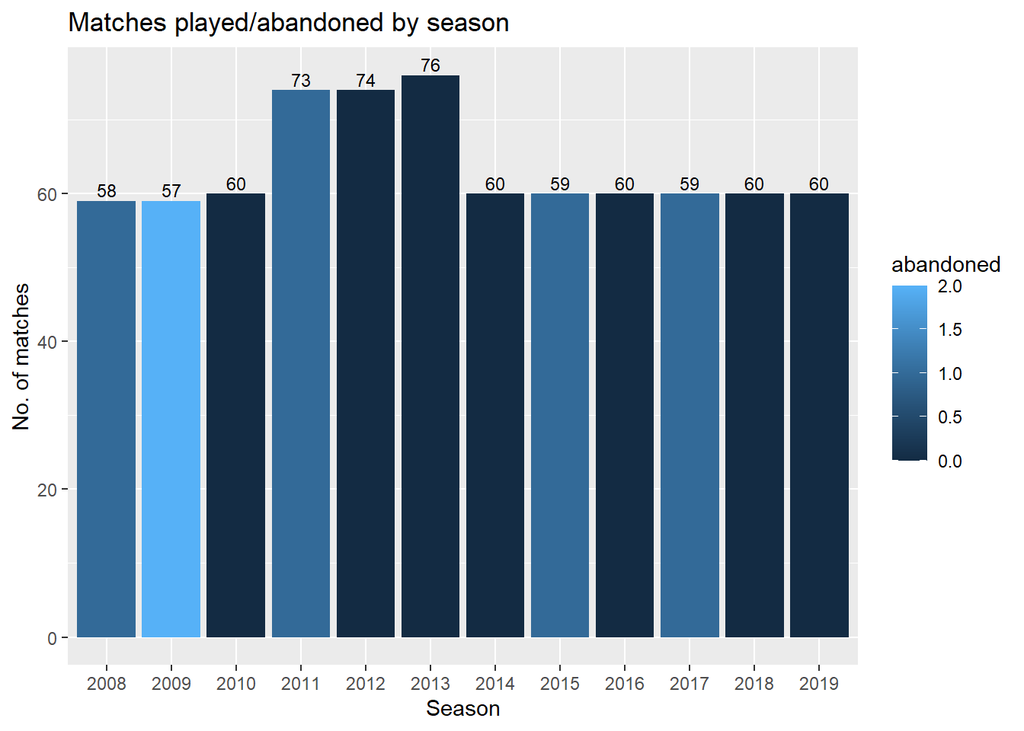

The visual shows the no. of matches played or completely abandoned per season

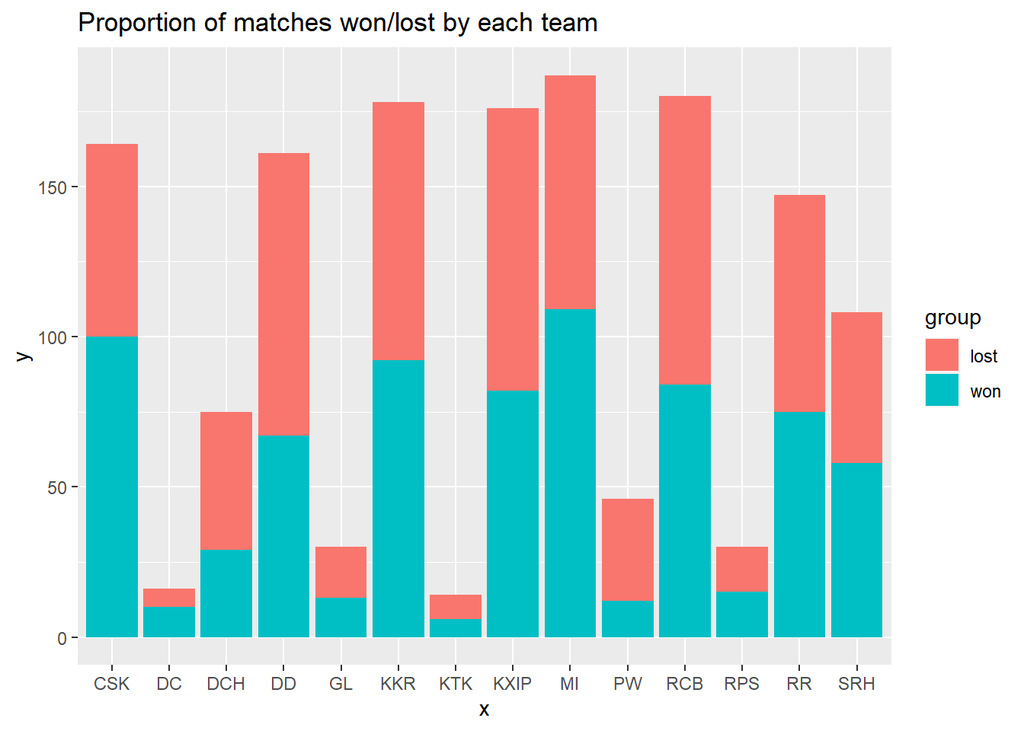

The visual clearly shows how CSK and MI have been consistent and successful over the years, DC too has a high proportion of success but over a very small sample size. The now defunct teams mostly had a poor record which contributed to the downfall of franchise. Some other teams like KKR, SRH and RR have always been mid-table with occasional titles which is reflected here. And then teams like KXIP and RCB are not too behind either but haven’t been able to cross the final hurdle.

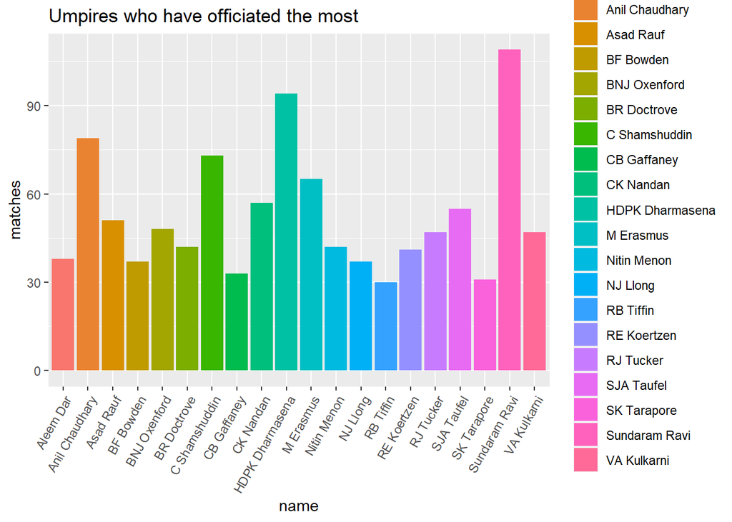

Majority of the umpires are elite panel umpires or have been elite panel umpires at their time. This is important as the level of umpiring goes a long way in contributing to the league’s success.

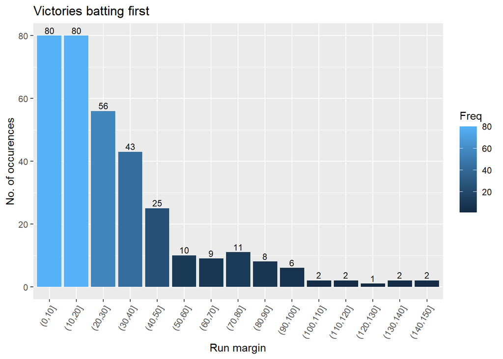

Almost 50% of the victories batting first have been under 20 runs which shows the league’s cut throat competition.

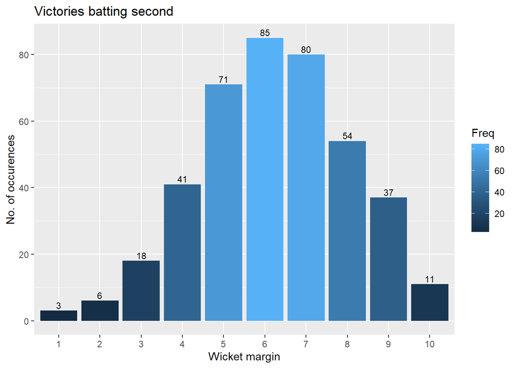

To the eye, it appears almost normally distributed which is manifested in the fact that good run chases are usually completed with 5-6 wickets remaining. However, fiery bowling performances usually leave the opponent reeling despite not winning and vice-versa for cold bowling performances.

No. of non-decisive games in regulation time

```
## [1] 13
```

No. of tied matches

```
## [1] 9
```